# Practical Machine Learning Assignment WirteUp

## Synopsis

### This Project was created as part of Practical Machine Learning course assignment to predict the manner in which they did the exercise. This is the “classe” variable in the training set. You may use any of the other variables to predict with. You should create a report describing how you built your model, how you used cross validation, what you think the expected out of sample error is, and why you made the choices you did. You will also use your prediction model to predict 20 different test cases.

### https://d396qusza40orc.cloudfront.net/predmachlearn/pml-training.csv

### https://d396qusza40orc.cloudfront.net/predmachlearn/pml-testing.csv

## Data Loading & Data Cleaning ( Training Data)

```r
setwd("D:\\Learning\\Coursera\\Data_Scientist\\Assignments\\Month8_Week4")
trainfileURL <- "https://d396qusza40orc.cloudfront.net/predmachlearn/pml-training.csv"
download.file(trainfileURL, destfile="pml-training.csv")
trainFile <- read.csv("pml-training.csv",na.strings=c('','NA'))
str(trainFile)
```

```
## 'data.frame':    19622 obs. of  160 variables:
##  $ X                       : int  1 2 3 4 5 6 7 8 9 10 ...
##  $ user_name               : Factor w/ 6 levels "adelmo","carlitos",..: 2 2 2 2 2 2 2 2 2 2 ...
##  $ raw_timestamp_part_1    : int  1323084231 1323084231 1323084231 1323084232 1323084232 1323084232 1323084232 1323084232 1323084232 1323084232 ...
##  $ raw_timestamp_part_2    : int  788290 808298 820366 120339 196328 304277 368296 440390 484323 484434 ...
##  $ cvtd_timestamp          : Factor w/ 20 levels "02/12/2011 13:32",..: 9 9 9 9 9 9 9 9 9 9 ...
##  $ new_window              : Factor w/ 2 levels "no","yes": 1 1 1 1 1 1 1 1 1 1 ...
##  $ num_window              : int  11 11 11 12 12 12 12 12 12 12 ...
##  $ roll_belt               : num  1.41 1.41 1.42 1.48 1.48 1.45 1.42 1.42 1.43 1.45 ...
##  $ pitch_belt              : num  8.07 8.07 8.07 8.05 8.07 8.06 8.09 8.13 8.16 8.17 ...
##  $ yaw_belt                : num  -94.4 -94.4 -94.4 -94.4 -94.4 -94.4 -94.4 -94.4 -94.4 -94.4 ...
##  $ total_accel_belt        : int  3 3 3 3 3 3 3 3 3 3 ...
##  $ kurtosis_roll_belt      : Factor w/ 396 levels "-0.016850","-0.021024",..: NA NA NA NA NA NA NA NA NA NA ...
##  $ kurtosis_picth_belt     : Factor w/ 316 levels "-0.021887","-0.060755",..: NA NA NA NA NA NA NA NA NA NA ...
##  $ kurtosis_yaw_belt       : Factor w/ 1 level "#DIV/0!": NA NA NA NA NA NA NA NA NA NA ...
```

[output cut: 86 more lines]

```r
dim(trainFile)
```

```
## [1] 19622   160
```

### From Above, we notice that lot of variables having blank & NA values, so filtering those values with NA into R.for which below commands will be used

```r
temp <-  trainFile[,!apply(trainFile,2,function(x) any(is.na(x)))]
pml_training <-  temp[,-c(1:7)]
dim(pml_training)
```

```
## [1] 19622    53
```

## Data Loading & Data Cleaning ( Test Data)

```r
setwd("D:\\Learning\\Coursera\\Data_Scientist\\Assignments\\Month8_Week4")
testfileURL <- "https://d396qusza40orc.cloudfront.net/predmachlearn/pml-testing.csv"
download.file(testfileURL, destfile="pml-testing.csv")
testFile <- read.csv("pml-testing.csv",na.strings=c('','NA'))
str(testFile)
```

```
## 'data.frame':    20 obs. of  160 variables:
##  $ X                       : int  1 2 3 4 5 6 7 8 9 10 ...
##  $ user_name               : Factor w/ 6 levels "adelmo","carlitos",..: 6 5 5 1 4 5 5 5 2 3 ...
##  $ raw_timestamp_part_1    : int  1323095002 1322673067 1322673075 1322832789 1322489635 1322673149 1322673128 1322673076 1323084240 1322837822 ...
##  $ raw_timestamp_part_2    : int  868349 778725 342967 560311 814776 510661 766645 54671 916313 384285 ...
##  $ cvtd_timestamp          : Factor w/ 11 levels "02/12/2011 13:33",..: 5 10 10 1 6 11 11 10 3 2 ...
##  $ new_window              : Factor w/ 1 level "no": 1 1 1 1 1 1 1 1 1 1 ...
##  $ num_window              : int  74 431 439 194 235 504 485 440 323 664 ...
##  $ roll_belt               : num  123 1.02 0.87 125 1.35 -5.92 1.2 0.43 0.93 114 ...
##  $ pitch_belt              : num  27 4.87 1.82 -41.6 3.33 1.59 4.44 4.15 6.72 22.4 ...
##  $ yaw_belt                : num  -4.75 -88.9 -88.5 162 -88.6 -87.7 -87.3 -88.5 -93.7 -13.1 ...
##  $ total_accel_belt        : int  20 4 5 17 3 4 4 4 4 18 ...
##  $ kurtosis_roll_belt      : logi  NA NA NA NA NA NA ...
##  $ kurtosis_picth_belt     : logi  NA NA NA NA NA NA ...
##  $ kurtosis_yaw_belt       : logi  NA NA NA NA NA NA ...
```

[output cut: 86 more lines]

```r
dim(testFile)
```

```
## [1]  20 160
```

### From Above, we notice that lot of variables having blank & NA values, so filtering those values with NA into R.for which below commands will be used

```r
temp = testFile[,!apply(testFile,2,function(x) any(is.na(x)) )]
pml_testing = temp[,-c(1:7)]
dim(pml_testing)
```

```
## [1] 20 53
```

## Cross Validation

### To achive cross validation, above training data will be split into 60:40 ratio.

```r
library('randomForest')
library('caret')
library('e1071')
```

```r
library('ggplot2')
library("rpart.plot")
crossVal <- createDataPartition(y=pml_training$classe, p=0.6, list=FALSE)
subTraining <- pml_training[crossVal,]
subTesting <-  pml_training[-crossVal,]
dim(subTraining)
```

```
## [1] 11776    53
```

```r
dim(subTesting)
```

```
## [1] 7846   53
```

## Modeling

### To predict the best model we start with regression & packaged trees and then find the accuracy of this model by using classe variable

```r
rpartModfit <- train(classe ~ .,method='rpart',data=subTraining)
```

### Now predicting the model with sub test data

```r
rpartPred <- predict(rpartModfit,newdata=subTesting)
rpartconfMat=confusionMatrix(rpartPred,subTesting$classe)
rpartconfMat$table
```

```
##           Reference
## Prediction    A    B    C    D    E
##          A 2015  631  635  567  214
##          B   35  499   43  230  187
##          C  176  388  690  489  398
##          D    0    0    0    0    0
##          E    6    0    0    0  643
```

```r
rpartconfMat$overall[1]
```

```
##  Accuracy
## 0.4903135
```

### From above Accuracy of comes to 0.5 for this Model fit. So rejecting this model and proceed with one of the Random Forest Method, Which is one of the most accurate predicting model to fit

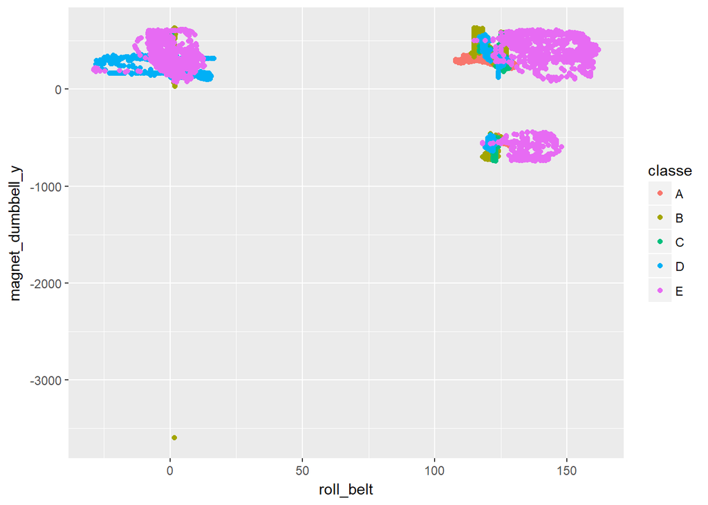

```r
rfModFit <- randomForest(classe~.,data=subTraining,method='class')
rfPred <- predict(rfModFit,subTesting,type='class')
qplot(roll_belt, magnet_dumbbell_y, colour=classe, data=subTraining)
```

### Now predicting the accuracy of random forest model

```r
rfconfMat=confusionMatrix(rfPred,subTesting$classe)
rfconfMat$table
```

```
##           Reference
## Prediction    A    B    C    D    E
##          A 2229    9    0    0    0
##          B    3 1506   10    0    0
##          C    0    3 1356   10    1
##          D    0    0    2 1275    2
##          E    0    0    0    1 1439
```

```r
rfconfMat$overall[1]
```

```
##  Accuracy
## 0.9947744
```

## Conclusion

### From the above, I can conclude that accuracy of random forest is very close to 1, So, I am considering this model is most accurate and proceeding with fitting this model on test data

```r
finalPred =  predict(rfModFit,pml_testing,type='class')
    nofiles = length(finalPred)
    for (i in 1:nofiles){
        filename =  paste0("problem_id",i,".txt")
        write.table(finalPred[i],file=filename,quote=FALSE,row.names=FALSE,col.names=FALSE)
    }
    finalPred
```

```
##  1  2  3  4  5  6  7  8  9 10 11 12 13 14 15 16 17 18 19 20
##  B  A  B  A  A  E  D  B  A  A  B  C  B  A  E  E  A  B  B  B
## Levels: A B C D E
```